# Current Algorithm Analysis

Lisa Oshita

October 26, 2018

```r
library(readr)
library(dplyr)
library(lubridate)
library(ggplot2)
```

# Objective

This markdown characterizes the current algorithm

- How accurate? (when the alg predicts that a text should be sent out - how accurate is it?)
- When, on average, is a text message triggered
- How often does it not work b/c data is missing.
- Seasonal pattern to wrong predictions?

```r
# === load data ========================================================
cdf <- read_csv("H:/TECH/Lisa/R/apcd.r/air.alerts/cdf.csv",
                skip = 3,
                col_names = c("Date", "WSV", "WDV", "ATM", "pm"))

# change date to date time
cdf <- cdf %>%
  mutate(Date = parse_date_time(Date, "d!-b!-Y! H!:M!")) %>%
  mutate(day = lubridate::date(Date))

arch.cdf <- read_csv("H:/TECH/Lisa/R/apcd.r/air.alerts/arch-cdf.csv",
                     col_types = list(wsv = "n", wdv = "n", sigt = "n",
                                      bam10 = "n", bam25 = "n", date = "c"))

arch.cdf <- arch.cdf %>%
  mutate(date = parse_date_time(date, "Y!-m!*-d! H!:M!:S!")) %>%
  mutate(day = lubridate::date(date)) %>%
  mutate(year = lubridate::year(date)) %>%
  filter(year > 2009) %>%
  select(-year)

colnames(arch.cdf)[4] <- "pm"

# === format data ======================================================
arch.cdf <- arch.cdf %>%
  mutate(pm = ifelse(pm > 800, NA, pm))

# remove days with < 75% completeness
to.remove <- arch.cdf %>%
  group_by(day) %>%
  summarize(prop.complete = 1 - sum(is.na(pm))/24) %>%
  filter(prop.complete < 0.75)

arch.cdf <- arch.cdf %>%
  filter(!day %in% to.remove$day) %>%
  mutate(hour = lubridate::hour(date))

rm(to.remove)
```

```r
# === manipulating data =================================================

# flag all hours with pm > 175 and after 8:00am
arch.cdf <- arch.cdf %>%
  mutate(send.alert = ifelse((pm >= 175) & (hour > 8), 1, 0))

# creating a new df with vars:
# - whether or not an alert was sent that day
# - the hour that the alert was sent
# - the actual 24 hr pm10 average
# - variable indicating if alg was correct (if actual avg >= 50 and an alert was sent, or if actual avg < 50 and no alert was sent)

cdf.stats <- arch.cdf %>%
  group_by(day) %>%
  summarize(alert.sent = ifelse(sum(send.alert, na.rm = TRUE) > 0, 1, 0),
            hour.sent = ifelse(sum(send.alert, na.rm = TRUE) == 0, NA, which(send.alert == 1)[1] - 1),
            actual.avg = mean(pm, na.rm = TRUE),
            was.correct = ifelse(((actual.avg >= 50) & (alert.sent == 1)) | ((actual.avg < 50) & (alert.sent == 0)), 1, 0))
```

```r
# === assessing accuracy ================================================

# =================
# overall accuracy
# =================
sum(cdf.stats$was.correct) / nrow(cdf.stats)
# current algorithm is correct 91.6% of the time (sends alert/doesn't send alert correctly)
# 220 days in 2010 - 2017 that the algorithm was incorrect

# ====================
# false positive rate
# ====================
sum((cdf.stats$alert.sent == 1) & (cdf.stats$was.correct == 0)) / nrow(cdf.stats)
# 3.5% of all days - algorithm sent out a text when the actual pm10 average did not exceed 50

# ====================
# false negative rate
# ====================
sum((cdf.stats$alert.sent == 0) & (cdf.stats$was.correct == 0)) / nrow(cdf.stats)
# 4.9% of all days - alg didn't send a text when actual pm10 avg was greater than 50

fp.fn.df <- cdf.stats %>%
  filter(was.correct == 0) %>%
  summarize(false.pos = sum(alert.sent == 1)/n(),
            false.neg = sum(alert.sent == 0)/n())
# out of all days that were predicted incorrectly - 41.8% are false positives, 58.2% are false negatives
```

# Accuracy

- The current algorithm is correct 91.6% of the time (it either sends and alert or doesn’t send an alert correctly)
  - From 2010 to 2017, there were 220 days when the algorithm was not correct
- Overall false positive rate: 3.5% of all days from 2010 to 2017 - the algorithm sent out a text alert when the actual pm10 average didn’t exceed 50
- Overall false negative rate: 4.9% of all days from 2010 to 2017 - the algorithm did not send out an alert text when the actual pm10 average was greater than 50.
- Out of all days that were predicted incorrectly:
  - 41.8% were false positives
  - 58.2% were false negatives

# Time of day when alerts are triggered

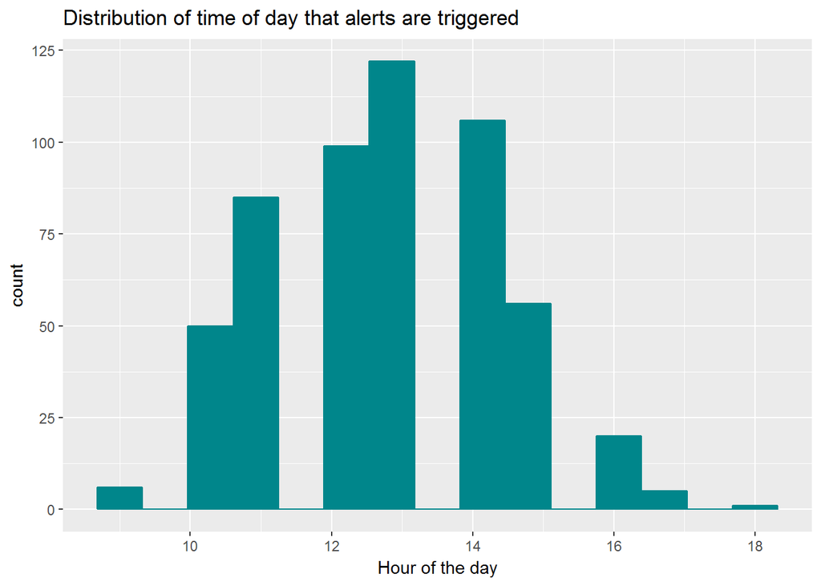

```r
# === time of day alerts are triggered ==================================

ggplot(cdf.stats, aes(x = hour.sent)) +
  geom_histogram(na.rm = TRUE, bins = 15, col = "turquoise4", fill = "turquoise4") +
  ggtitle("Distribution of time of day that alerts are triggered") +
  xlab("Hour of the day")
```

```r
min(cdf.stats$hour.sent, na.rm = TRUE) # earliest is 9:00
```

```
## [1] 9
```

```r
max(cdf.stats$hour.sent, na.rm = TRUE) # latest is 18:00
```

```
## [1] 18
```

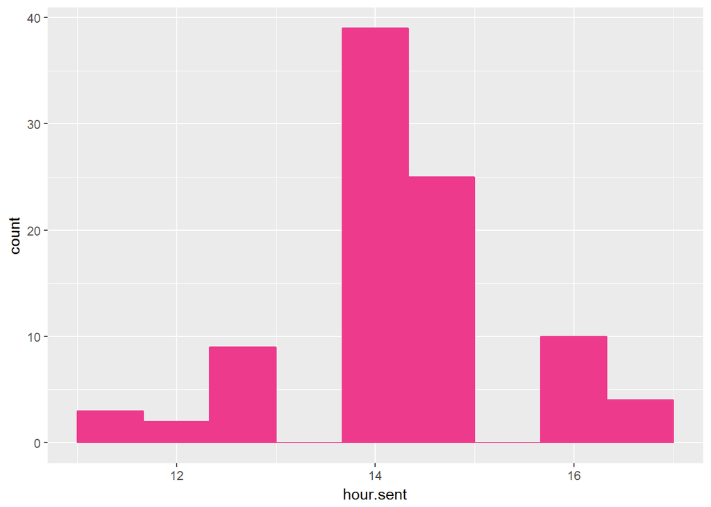

```r
# is there a pattern to the hour of the day when the alert is incorrect?
# pattern to the month/year that an alert is incorrect?
# pattern to the days that a text wasn't sent out but should have?

# histogram of the hours of the day that a text was sent out when it shouldn't have been
cdf.stats %>%
  filter(was.correct == 0) %>%
  ggplot(aes(x = hour.sent)) +
  geom_histogram(na.rm = TRUE, bins = 10, col = "violetred2", fill = "violetred2")
```

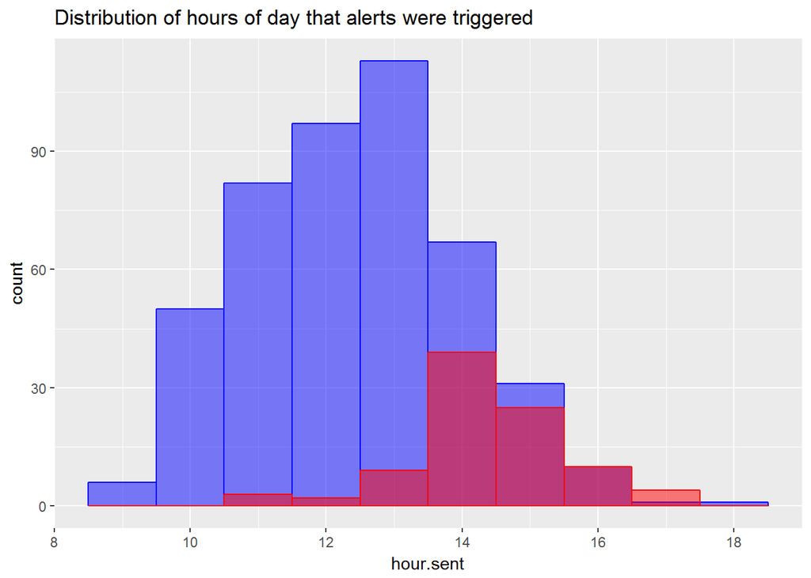

```r
# overlaying the histograms
ggplot(cdf.stats, aes(x = hour.sent)) +
  geom_histogram(data = subset(cdf.stats, was.correct == 1), fill = "blue", col = "blue", alpha = 0.5, bins = 10, na.rm = TRUE) +
  geom_histogram(data = subset(cdf.stats, was.correct == 0), fill = "red", col = "red", alpha = 0.5, bins = 10, na.rm = TRUE) +
  ggtitle("Distribution of hours of day that alerts were triggered")
```